# ML Final Blog Post

Camden Droz

# 1 Machine Learning Final Project: Allowable-Torque Prediction for Gears

## 1.1 Background

When designing a mechanical system that utilizes gears, it is important as an engineer to understand the loading case acting on the system and how any applied loads or moments will affect the gears in order to prevent them from yielding or breaking during operation. As such, an engineer can account for any forces or torques being applied to the gears in the system by ensuring the geometric properties of the gears allow them to bear the maximum possible load on them without yielding or deforming (a gear’s allowable torque). However, it is not the simplest process to identify this value, as many of the modifier constants that can alter the torque value (surface condition, temperature, etc.) are not always easily identifiable unless otherwise specified by the manufacturer, as these values are produced through material testing inaccessible by the average engineer. The purpose of this project is to create a model architecture that, given the geometric features of a gear, can predict the allowable torque of that gear before yielding, with the goal that a gear could hypothetically be chosen from a shop space at random and the model can predict the allowable torque on the gear with a high accuracy.

## 1.3 Important Considerations

All gears used in training, testing, and validation come from the KHK Gears manafacturers website and all gears are made of steel, contain a keyway, and are spur gears. This was done to, firstly, standardize the torque and modifier constant calculations the dataset uses by selecting a single manafacturer to scrape data from, and secondly, to simplify the gears used in the dataset to qualities present in almost all gears you could find in the shop (i.e. made of steel and containing a keyway). Furthermore, it is important to keep in mind that the goal of the project is not to replace the need of cheking a gear’s specifications on the manafacturer’s website to ensure it can withstand the loads applied to the system, but rather to provide an alternative in the case where it would prove to be a significant challenge to identify a gear’s origins in order to identify its load specifications.

## 1.4 Gear Geometric Qualities Dictionary

- **Teeth Count**

The number of teeth that cover the circumference of the gear and are what transfer torque between gears.

- **Pitch Diameter**

The diameter of the pitch circle, which is an imaginary circle that illustrates the point at which two gears create contact through a tangent line to the pitch circle.

- **Module**

A metric unit that describes the size and shape of a gear by measuring the ratio of its pitch diameter to the number of teeth.

- **Bore Diameter**

The diameter of the inner hole, or bore, that the shaft the gear sits on resides in.

- **Face Width**

The width of a single tooth on the gear, in the case of a spur gear can be likened to the thickness of the gear.

- **Allowable Torque**

The amount of rotational force that can be applied to the gear through the input shaft before the gear yields (breaks) or permanently deforms and prevent further operation.

- **Weight**

The mass of the gear, however for simplicity in this project, I will refer to the mass as the weight of the gear in kilograms.

- **Lewis Form Factor**

A dimensionless constant that represents a gear tooth’s ability to withstand bending stresses depending on its shape.

## 1.5 Data Scraping

In order to extract all of the data for this project, I scraped the KHK Gears website for the geometric specifications of the gears as well as their allowable torque and weight. The initial data set of gear model numbers and their geometric qualities were copied directly from the website and stored in a CSV on my github. I then used Playwright and BeautifulSoup to create a Chrome browser instance that could load the page for each specific gear listed in a data frame of all gears from the website, as the torque and weight data for each gear was stored in a Javascript script that could not be parsed from just the HTML of the page. This data was then stored in a data frame and then exported to a CSV locally to be combined with the originally parsed gear data. A picture of the output of the scraping is shown below.

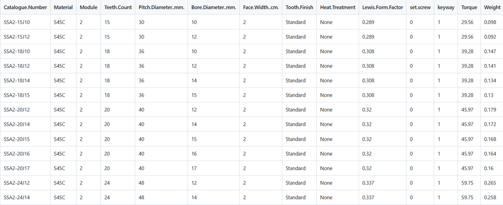

## 1.6 Analysis of Input Data

Before creating a model architecture to predict allowable torque, I first wanted to better understand and visualize the landscape and variance of the data to provide more context in regards to the input data before moving forward.

### 1.6.1 Correlation Matrix

To first get a better understanding of how each feature of the dataset relates to each other, I made a correlation matrix that displays how correlated any two features are to one another, either positively or negatively and to what degree (strength) from -1 to 1. For example, we can see from this matrix that ‘Torque’ and ‘Weight’ are significantly strongly correlated with a score of 0.96, suggesting that a gear’s allowable torque increases almost directly proportionally with its weight.

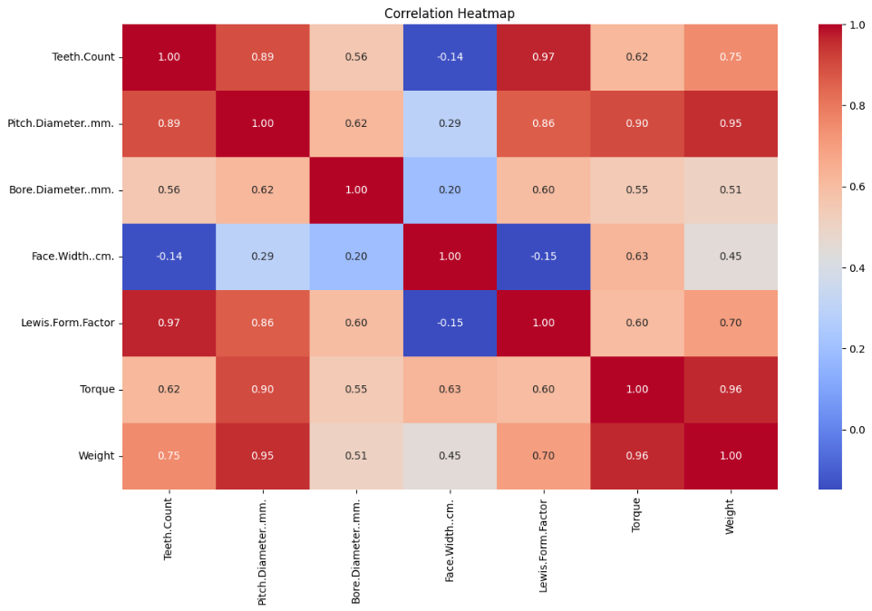

### 1.6.2 Gear Feature Hexbins

Next, I created a hexbin plot for each of the features of the dataset to visually express the distribution of geometric values present in the dataset and the trend in allowable torque for each value. Each plot uses a colorbar to denote how many gears fall into each value bin for each geometric value. An interesting insight is that while for most values there is a slightly positive relationship, although the exact strength is difficult to identify as there seem to be multiple “paths” in the trends, for a gear’s weight the relationship is actually quite strongly positive.

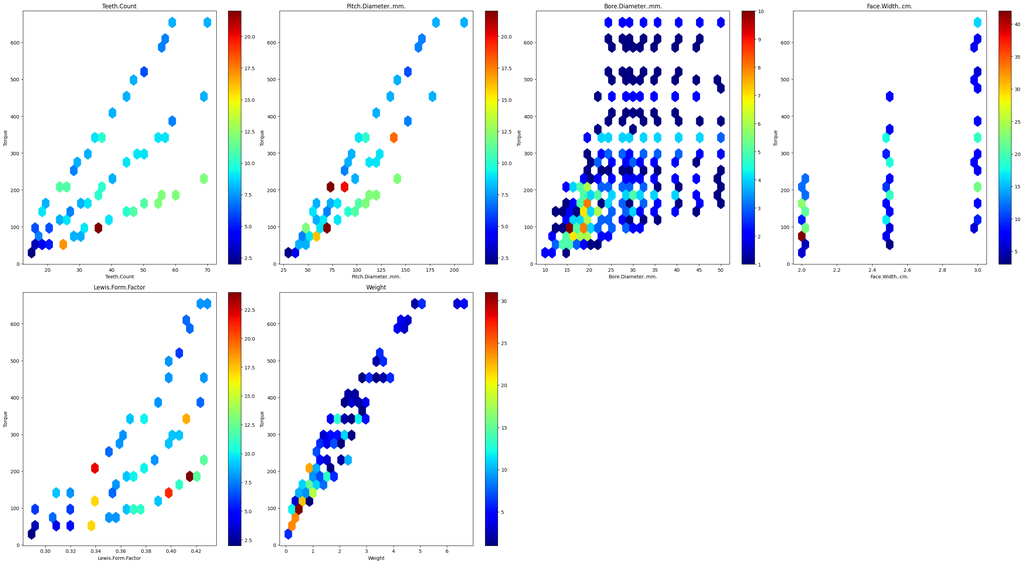

## 1.7 Introduction to Machine Learning

### 1.7.1 Linear Regression

To approach this project, I started with a basic linear regression model for predicting the allowable torque rating of a new gear. In simplest terms, a linear regression model finds a straight line that best fits the data, and then uses this line to predict a future value based on features given about the new value. In the context of this problem, a linear regression model is going to create a line that fits to the data about a gear’s geometry and its resulting torque rating, and then when presented the features of a new gear will pick the point on the fit line closest to these features in order to predict the allowable torque of this new gear. A video I found helpful for explaining the concept in more detail can be found here: https://www.youtube.com/WkVvZreJtmU?si=WXudvsrH_7iR9mxp

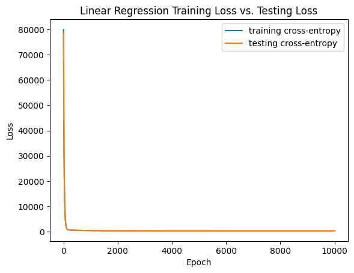

Despite its initial drop from a very high loss, it landed around a testing loss of 277, so considering I used a Mean Squared Error (MSE) loss function, that means that the model had an average error of 16.6 between the actual and predicted values.

### 1.7.2 Neural Network

To further increase the accuracy of my model, I opted for a Neural Network architecture for regression. A Neural Network is a computational model inspired by how the human brain works, consisting of layers of interconnected nodes that are much better equipped to encoding complex patterns from the data than a simple linear regression. A neural network consists of three layers: an input layer, a hidden layer, and an output layer, and within the hidden layer can be any number of node layers within this larger layer. In the input layer is one node for each feature of the input data, so in our case there is one node for each geometric quality of a gear that the data takes into account. The hidden layer is where the magic happens and the model learns patterns in the data. In each node of the hidden layer a separate linear regression is applied that seeks to learn the relationships between the input variables. The output layer, in our case, is a singular node that takes the encoded patterns and determines a single output value, and in this context that value would be the allowable torque of the gear. The visual below demonstrates the basic structure of a Neural Network for regression, and I have also included the link to a great video explaining the basics of a Neural Network here: https://youtu.be/jmmW0F0biz0?si=rslTnpt1zUjnXK6m

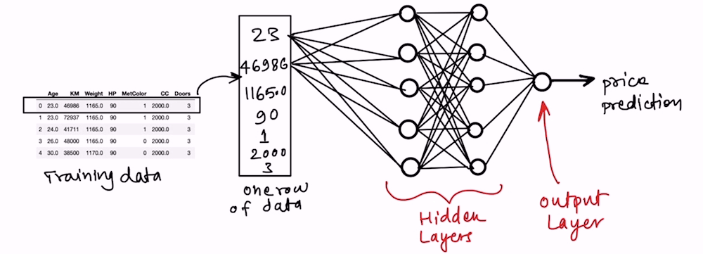

This model was much more effective at learning the patterns of the dataas the model had an overall testing loss of 2.05, meaning the model had an average error from predicted to actual value of 1.43. Because of this much higher accuracy compared to the original model, moving forward I wanted to test the capabilites of the Neural Network with a real-world exmaple.

## 1.8 Real-World Gear Test

To further test the capabilities of the model, I grabbed one of the gears in the current design of Olin Baja’s drivetrain gearbox and measured all of the necessary features to input the gear into the model. The predicted allowable torque by the model was 62.48 Nm, which is fairly close to the actual allowable torque of this gear of 73.92 Nm, and still has a factor of safety of over 2 when compared to the input torque of 25 Nm on the shaft by the car’s engine.

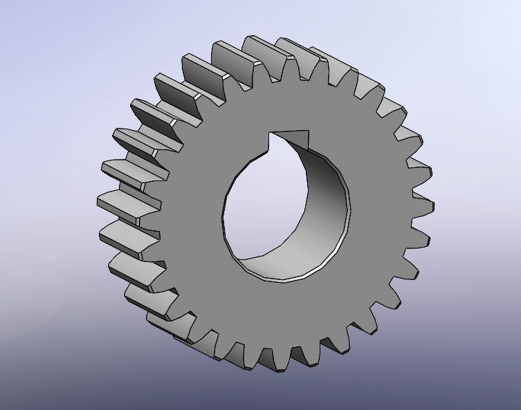

After getting the model output for this gear, I took the CAD file for the gear provided by the manufacturer and ran a Solidworks FEA Simulation of a loading case where a torque just below the allowable torque predicted by the model was applied to the gear. The simulation proved the model’s prediction to be accurate in that the gear was well below its yield stress as a result of the applied torque that was only slightly below the predicted allowable torque of the gear.

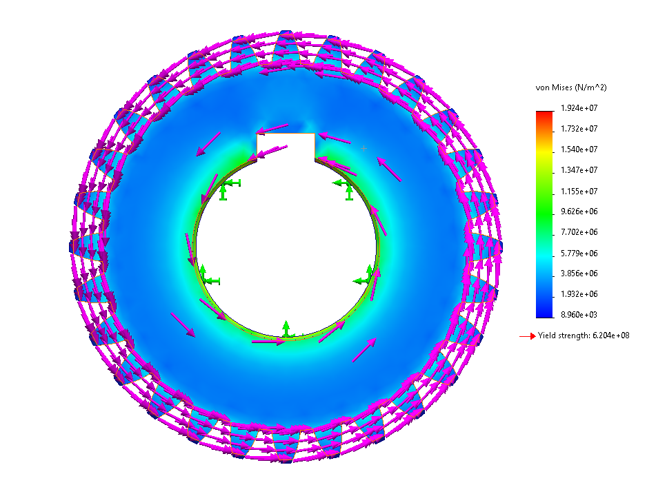